# Is there still an enrichment of CT genes on the X chromosome if we take duplicated genes in family into account ?

Julie Devis

2024-10-18

```r
.libPaths("/storage/research/dduv/cbio-lg/rlib/Bioc320", include.site = FALSE)
library(CTexploreR)
library(tidyverse)
```

We’ve shown that there is an enrichment of CT genes on the X chromosome, and that this enrichment was only seen for genes that are MethDep. However, we wonder if this would still be seen if we take into account the fact that many CT genes are duplication of each other as they’re from the same families.

```r
CT_genes <- CT_genes %>%
  filter(CT_gene_type == "CT_gene")
table(CT_genes$family)
```

```
##
## CT45A  CTAG  GAGE  MAGE  PAGE  RBMY SPANX   SSX  TSPY   VCX
##     8     3     7    18     3     3     3     4     5     4
```

```r
sum(table(CT_genes$family))
```

```
## [1] 58
```

```r
table(CT_genes$family, CT_genes$chr)
```

```
##
##          1 10 11 12 13 14 15 16 17 18 19  2 20 21  3  4  5  6  7  8  9  X  Y
##   CT45A  0  0  0  0  0  0  0  0  0  0  0  0  0  0  0  0  0  0  0  0  0  8  0
##   CTAG   0  0  0  0  0  0  0  0  0  0  0  0  0  0  0  0  0  0  0  0  0  3  0
##   GAGE   0  0  0  0  0  0  0  0  0  0  0  0  0  0  0  0  0  0  0  0  0  7  0
##   MAGE   0  0  0  0  0  0  0  0  0  0  0  0  0  0  0  0  0  0  0  0  0 18  0
##   PAGE   0  0  0  0  0  0  0  0  0  0  0  0  0  0  0  0  0  0  0  0  0  3  0
##   RBMY   0  0  0  0  0  0  0  0  0  0  0  0  0  0  0  0  0  0  0  0  0  0  3
##   SPANX  0  0  0  0  0  0  0  0  0  0  0  0  0  0  0  0  0  0  0  0  0  3  0
##   SSX    0  0  0  0  0  0  0  0  0  0  0  0  0  0  0  0  0  0  0  0  0  4  0
##   TSPY   0  0  0  0  0  0  0  0  0  0  0  0  0  0  0  0  0  0  0  0  0  0  5
##   VCX    0  0  0  0  0  0  0  0  0  0  0  0  0  0  0  0  0  0  0  0  0  4  0
```

```r
table(CT_genes$family, CT_genes$regulated_by_methylation)
```

```
##
##         FALSE TRUE
##   CT45A     0    8
##   CTAG      0    3
##   GAGE      0    7
##   MAGE      0   18
##   PAGE      0    3
##   RBMY      0    3
##   SPANX     0    3
##   SSX       0    4
##   TSPY      5    0
##   VCX       0    4
```

There are 10 families containing 58 genes.

```r
CT_no_duplicated_fam <- CT_genes %>%
  filter(!duplicated(family) | is.na(family)) %>%
  mutate(Regulation = case_when(regulated_by_methylation ~ "Methylation",
                                !regulated_by_methylation ~ "Not methylation")) %>%
  mutate(Chr = case_when(X_linked ~ "X-linked",
                         !X_linked ~ "not X"))
dim(CT_no_duplicated_fam)
```

```
## [1] 98 49
```

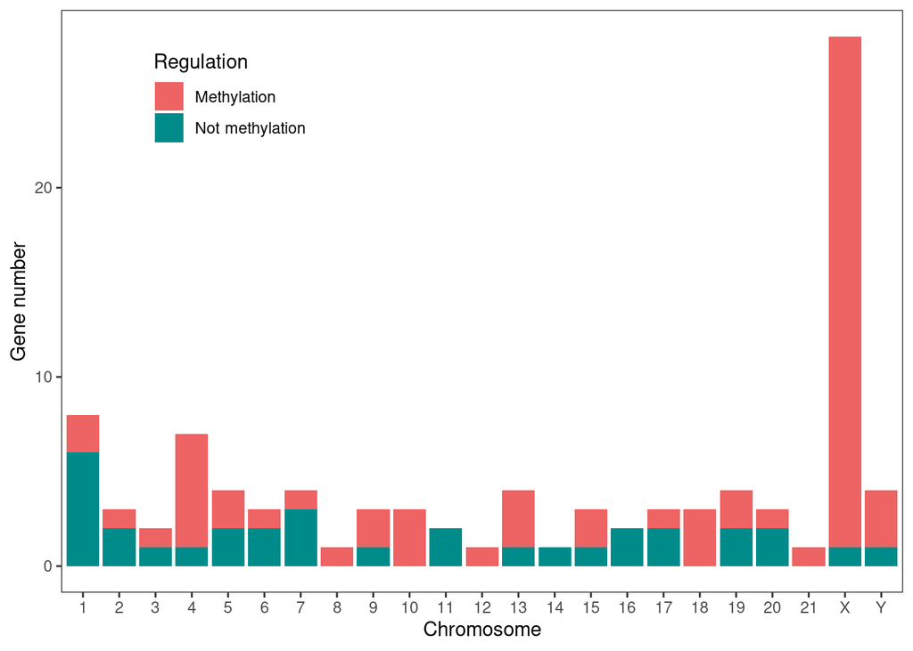

```r
CT_no_duplicated_fam$chr <- factor(CT_no_duplicated_fam$chr, levels = c(1:22, "X", "Y"))

fig_X_enrichment <- ggplot(CT_no_duplicated_fam %>%
                             filter(!is.na(regulated_by_methylation)),
                           aes(x = chr, fill = Regulation)) +
  geom_bar(stat = 'count') +
  xlab("Chromosome") +
  ylab("Gene number") +
  scale_fill_manual(values = c("Methylation" = "indianred2",
                               "Not methylation"= "cyan4"))+
  theme_bw() +
  theme(legend.position = "inside",
        legend.position.inside = c(0.2, 0.85),
        #aspect.ratio = 1.5,
        panel.grid = element_blank())

fig_X_enrichment
```

```r
table(CT_no_duplicated_fam$chr)
```

```
##
##  1  2  3  4  5  6  7  8  9 10 11 12 13 14 15 16 17 18 19 20 21 22  X  Y
##  9  3  2  7  4  3  4  1  3  3  2  1  4  1  3  2  3  3  4  3  1  0 28  4
```

```r
CT_no_duplicated_fam_rep <- CT_no_duplicated_fam %>%
  filter(!is.na(regulated_by_methylation)) %>%
  group_by(Regulation, Chr) %>%
  dplyr::count() %>%
  pivot_wider(names_from = Regulation, values_from = n)

CT_no_duplicated_fam_rep
```

| Chr | Methylation | Not methylation |
| --- | --- | --- |
| X-linked | 27 | 1 |
| not X | 37 | 32 |

```r
chisq.test(CT_no_duplicated_fam_rep[,-1])
```

```
##
##  Pearson's Chi-squared test with Yates' continuity correction
##
## data:  CT_no_duplicated_fam_rep[, -1]
## X-squared = 14.407, df = 1, p-value = 0.0001472
```

We can still see that there is more genes on the X chromosome than on others. However, in comparison with the analysis not removing duplicated families, the MethDep repartition between X and not X is different, as there is now more genes that are not X (37 out of the initial 39) than those that are X-linked (27 out of the 69). However, pvalue is still significative.

Could also be done by autosomes/X

```r
CT_genes_X_linked <- CT_no_duplicated_fam %>%
  mutate(chr = case_when(chr == "X" ~ "X-linked",
                           chr == "Y" ~ "Y-linked",
                           !chr %in% c("X", "Y") ~ "Autosome")) %>%
  filter(!is.na(regulated_by_methylation)) %>%
  group_by(Regulation, chr) %>%
  dplyr::count() %>%
  pivot_wider(names_from = Regulation, values_from = n)
CT_genes_X_linked
```

| chr | Methylation | Not methylation |
| --- | --- | --- |
| Autosome | 34 | 31 |
| X-linked | 27 | 1 |
| Y-linked | 3 | 1 |

What does it give if we normalise according to the number of gene per chromosome ?

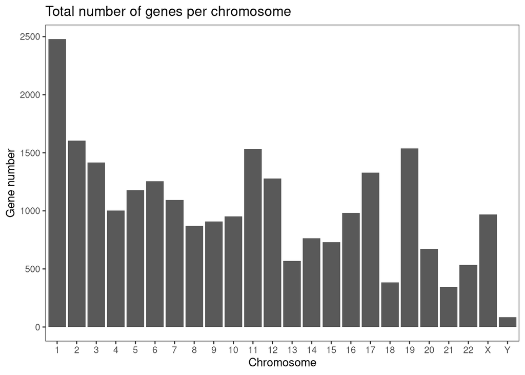

```r
n_genes_per_chr <- all_genes %>%
  filter(chr != "MT") %>%
  group_by(chr) %>%
  summarize(n = n()) %>%
  mutate(chr = factor(chr, levels = c(1:22, "X", "Y"))) %>%
  arrange(chr)

n_genes <- n_genes_per_chr %>%
  filter(!chr %in% "MT") %>%
  pull(n) %>%
  sum()
n_genes_autosome <- n_genes_per_chr %>%
  filter(chr %in% 1:22) %>%
  pull(n) %>%
  sum()
n_genes_X <- n_genes_per_chr %>%
  filter(chr %in% "X") %>%
  pull(n)
n_genes_Y <- n_genes_per_chr %>%
  filter(chr %in% "Y") %>%
  pull(n)

n_genes_per_chr_autosome_X_Y <- tibble("chr" = c("Autosome", "X-linked", "Y-linked"),
       n = c(n_genes_autosome, n_genes_X, n_genes_Y))

ggplot(n_genes_per_chr, aes(x = chr, y = n)) +
  geom_col() +
  xlab("Chromosome") +
  ylab("Gene number") +
  scale_fill_manual(values = c("Methylation" = "indianred2",
                               "Not methylation"= "cyan4")) +
  theme_bw() +
  theme(legend.position = "inside",
        legend.position.inside = c(0.2, 0.85),
        #aspect.ratio = 1.5,
        panel.grid = element_blank()) +
  ggtitle("Total number of genes per chromosome")
```

```r
n_genes_per_chr_autosome_X_Y <- n_genes_per_chr_autosome_X_Y %>%
  mutate(proba = n / n_genes)
n_genes_per_chr_autosome_X_Y
```

| chr | n | proba |
| --- | --- | --- |
| Autosome | 23422 | 0.956976507 |
| X-linked | 968 | 0.039550562 |
| Y-linked | 85 | 0.003472932 |

```r
CT_genes_Met <- colSums(CT_genes_X_linked[, -1])["Methylation"]
CT_genes_not_Met <- colSums(CT_genes_X_linked[, -1])["Not methylation"]
CT_genes_X_Y_observed_expected <- CT_genes_X_linked %>%
  left_join(n_genes_per_chr_autosome_X_Y %>%
              dplyr::select(-n)) %>%
  mutate(Expected_MET_if_random = (CT_genes_Met * proba),
         Expected_NOT_MET_if_random = (CT_genes_not_Met * proba)) %>%
  dplyr::select(chr, Methylation, Expected_MET_if_random, `Not methylation`, Expected_NOT_MET_if_random)
CT_genes_X_Y_observed_expected
```

| chr | Methylation | Expected_MET_if_random | Not methylation | Expected_NOT_MET_if_random |
| --- | --- | --- | --- | --- |
| Autosome | 34 | 61.2464964 | 31 | 31.5802247 |
| X-linked | 27 | 2.5312360 | 1 | 1.3051685 |
| Y-linked | 3 | 0.2222676 | 1 | 0.1146067 |

```r
chisq.test(CT_genes_X_Y_observed_expected[
  CT_genes_X_Y_observed_expected$chr %in% c("Autosome", "X-linked"), c("Methylation", "Expected_MET_if_random")])
```

```
##
##  Pearson's Chi-squared test with Yates' continuity correction
##
## data:  CT_genes_X_Y_observed_expected[CT_genes_X_Y_observed_expected$chr %in%     c("Autosome", "X-linked"), c("Methylation", "Expected_MET_if_random")]
## X-squared = 25.834, df = 1, p-value = 3.72e-07
```

CT genes regulated by met are enriched on X when taking into account the number of genes per chromosome, verified statistically.

*Laurent’s questioning : Pourquoi est-ce que ce sont les CT sur le X qui ont subi une duplication ? Est-ce qu’il y aurait eu une pression de l’évolution qui fait qu’il y ait une duplication sur le X qui est favorisée ? Y-aurait-il un sens embryo ?*